# SECTION 4: PROGRAMMING BASICS

R is not just a data analysis environment but also a programming language. Three key programming concepts are: conditional expressions, for-loops, and functions.

### 4.1 Conditional expressions

Conditional expressions are used for what is called *flow control*.

- **if-else** statement: most common conditional expression.

```r
a <- 0
if(a != 0){
  print(1/a)
} else{
  print("No reciprocal for 0.")
}
```

```
## [1] "No reciprocal for 0."
```

Using the US murder data frame:

```r
library(dslabs)
data(murders)
murder_rate <- murders$total / murders$population * 100000
```

Determine which states have a murder rate lower than 0.5 per 100,000:

```r
ind <- which.min(murder_rate)
if(murder_rate[ind] < 0.5){
  print(murders$state[ind])
} else {
  print("No state has murder rate that low")
}
```

```
## [1] "Vermont"
```

If we try again with a rate of 0.25, we get a different answer.

```r
if(murder_rate[ind] < 0.25){
  print(murder$state[ind])
} else {
  print ("No state has murder rate that low")
}
```

```
## [1] "No state has murder rate that low"
```

- `ifelse()`: takes 3 arguments (a logical and two possible answers). If the logical is `TRUE`, the value in the second argument is returned. If `FALSE`, the value in the third argument is returned.

```r
a <- 0
ifelse(a > 0, 1/a, NA)
```

```
## [1] NA
```

`ifelse` works on vector: examines each entry of the logical vector.

```r
a <- c(0, 1, 2 , -4, 5 )
result <- ifelse(a > 0, 1/a, NA)
```

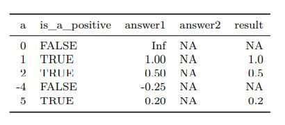

Use `ifelse` to replace all missing values in a vector with zeros:

```r
data("na_example")
no_nas <- ifelse(is.na(na_example), 0, na_example)
sum(is.na(no_nas))
```

```
## [1] 0
```

The function `ifelse` is useful because you convert a vector of logicals into something else. For example, some datasets use the number -999 to denote NA. A bad practice! You can convert the -999 in a vector to NA using `ifelse` call:

```r
x <- c(2, 3, -999, 1, 4, 5, -999, 3, 2, 9)
ifelse(x == -999, NA, x)
```

```
##  [1]  2  3 NA  1  4  5 NA  3  2  9
```

- `nchar()`: tells you how many characters long a character vector is.

```r
char_len <- nchar(murders$state)
head(char_len)
```

```
## [1]  7  6  7  8 10  8
```

Assign the state abbreviation when the state name is longer than 8 characters:

```r
ifelse(nchar(murders$state) > 8, murders$abb, murders$state)
```

```
##  [1] "Alabama"  "Alaska"   "Arizona"  "Arkansas" "CA"       "Colorado"
##  [7] "CT"       "Delaware" "DC"       "Florida"  "Georgia"  "Hawaii"
## [13] "Idaho"    "Illinois" "Indiana"  "Iowa"     "Kansas"   "Kentucky"
## [19] "LA"       "Maine"    "Maryland" "MA"       "Michigan" "MN"
## [25] "MS"       "Missouri" "Montana"  "Nebraska" "Nevada"   "NH"
## [31] "NJ"       "NM"       "New York" "NC"       "ND"       "Ohio"
## [37] "Oklahoma" "Oregon"   "PA"       "RI"       "SC"       "SD"
## [43] "TN"       "Texas"    "Utah"     "Vermont"  "Virginia" "WA"
## [49] "WV"       "WI"       "Wyoming"
```

- `any()`: takes a vector of logicals and returns `TRUE` if any of the entries is `TRUE`.
- `all()`: takes a vector of logicals and returns `TRUE` if all of the entries are `TRUE`.

```r
z <- c(TRUE, TRUE, FALSE)
any(z)
```

```
## [1] TRUE
```

```r
all(z)
```

```
## [1] FALSE
```

The expressions is always `FALSE` when at least one entry of a logical vector x is `TRUE`.

```r
all(!x)
```

```
## [1] FALSE
```

Combine with **if-else** conditional:

```r
x <- c(1,2,-3,4)
if(all(x>0)){
  print("All Positives")
} else{
  print("Not All Positives")
}
```

```
## [1] "Not All Positives"
```

### 4.2 Functions

As you become more experienced, you will need to perform the same operations over and over, for example, computing the average of vector `x` by using the `sum(x)/length(x)`. It is more efficient to write a function for this operation.

```r
avg <- function(x){
  s <- sum(x)
  n <- length(x)
  s/n
}
x <- 1:100
avg(x)
```

```
## [1] 50.5
```

R already provides the function `mean(x)` for computing averages.

```r
identical(mean(x), avg(x)) # returns the same result.
```

```
## [1] TRUE
```

Variables defined inside a function are not saved in the workspace. While we use `s` and `n` when we call `avg`, the values are created and changed only during the call. In general, functions are objects that are assigned with `<-`. `function()` tells R to define a function.

Defined functions can have multiple arguments as well as default values. For example, define a function that computes either the arithmetic or geometric average depending on a user-defined variable:

```r
avg <- function(x, arithmetic = TRUE){
  n <- length(x)
  ifelse(arithmetic, sum(x/n), prod(x)^(1/n))
}
```

Create function called `sum_n` that for any given value, say `n`, creates the vector `1:n`, and then computes the sum of the integers from 1 to n:

```r
sum_n <- function(n){
  sum(1:n)
}
```

Use the function to determine the sum of integers from 1 to 5000:

```r
sum_n(5000)
```

```
## [1] 12502500
```

Functions could be defined with multiple variables.

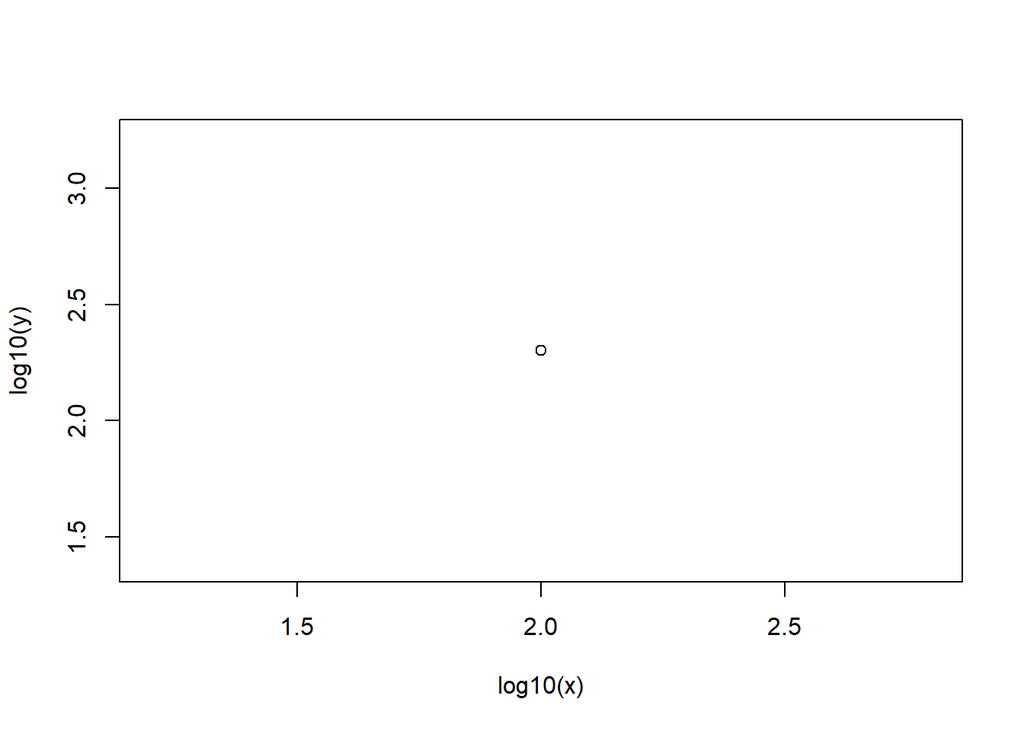

```r
log_plot <- function(x, y){
  plot(log10(x), log10(y))
}
log_plot(100, 200)
```

This function does not return anything. It just makes a plot.

*Lexical scoping* is a convention used by many languages that determine when an object is available by its name. When you run the code below you will see which `x` is available at different points in the code.

```r
x <- 8
my_func <- function(y){
    x <- 9
    print(x)
    y + x
}
my_func(x)
```

```
## [1] 9
```

```
## [1] 17
```

```r
print(x)
```

```
## [1] 8
```

When we define `x` as 9, this is inside the function, but it is 8 after you run the function. The `x` changed inside the function but not outside.

### 4.3 For-loops

**For-loops** perform the same task over and over while changing the variable. For example, write a function to calculate the sum Sn = 1 + 2 + 3 +…+ n.

```r
compute_s_n <- function(n){
  x <- 1:n
  sum(x)
}
```

How can we compute `Sn` for various values of `n`, for example, 25? Do we write 25 lines of code calling `compute_s_n`? For-loops let us define the range the variable takes, then change the value and evaluate expression as you loop.

```r
for(i in 1:5){
  print(i)
}
```

```
## [1] 1
## [1] 2
## [1] 3
## [1] 4
## [1] 5
```

Write the for-loop for `Sn`:

```r
n <- 1:25
s_n <- vector("numeric", 25) # create an empty vector to store data
for(i in n){
  s_n[i] <- compute_s_n(i)
}
```

In each iteration n = 1, n = 2, etc…, we compute Sn and store it in the nth entry of `s_n`.

Create a plot to search for a pattern:

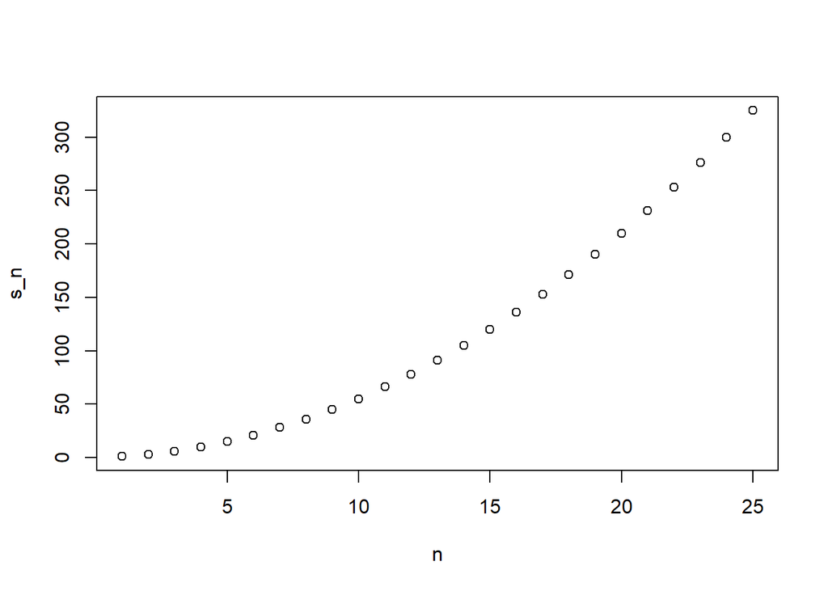

```r
plot(n, s_n)
```

The plot appears to be a quadratic, that match the formula 1 + 2 +…+ n = n(n+1)/2.

Write a function with argument `n` that for any given `n` computes the sum of 1 + 2^2 + …+ n^2.

```r
compute_s_n2 <- function(n){
  n*(n+1)*(2*n+1)/6
}
```

Report the value of the sum when n = 10:

```r
compute_s_n2(10)
```

```
## [1] 385
```

Write for-loop:

```r
for(i in n){
  s_n[i] <- compute_s_n2(i)
}
```

Check that `s_n` is identical to the mathematical formula:

```r
identical(s_n, n*(n+1)*(2*n+1)/6)
```

```
## [1] TRUE
```

### 4.4 Vectorization and functionals

Although for-loops are an important concept, they are rarely used in R. *Vectorization* and *functionals* are actually preferred over for-loops since it results in shorter and clearer code.

- *Vectorized function*: a function that will apply the same operation on each of the vectors.

```r
x <- 1:10
sqrt(x)
```

```
##  [1] 1.000000 1.414214 1.732051 2.000000 2.236068 2.449490 2.645751 2.828427
##  [9] 3.000000 3.162278
```

```r
y <- 1:10
x*y
```

```
##  [1]   1   4   9  16  25  36  49  64  81 100
```

To make these calculations, there is no need for for-loops. However, not all function works element-wise. For example, `compute_s_n` is expecting a scalar.

```r
n <- 1:25
compute_s_n(n) # This doesn't run on each entry of n.
```

```
## [1] 1
```

- *Functionals*: funtions that help us apply the same function to each entry in a vector, matrix, data frame, or list. For example, `sapply()` permits us to perform element-wise operations on any function.

```r
x <- 1:10
sapply(x, sqrt)
```

```
##  [1] 1.000000 1.414214 1.732051 2.000000 2.236068 2.449490 2.645751 2.828427
##  [9] 3.000000 3.162278
```

The result is a vector that has the same length.